# Dimensionality Reduction Techniques

In this chapter, we will practice dimensionality reduction techniques using “human” data which was originated from the United Nations Development Programme (UNDP). Additional information about the data can be found [here](http://hdr.undp.org/en/content/human-development-index-hdi).

## RStudio Exercise 5

**Data Exploration**

First we will load the data into R and get an overview of it.

```r
human<-read.table("data/human.csv")
#head(human)
dim(human)
```

```
## [1] 155   8
```

```r
str(human)
```

```
## 'data.frame':    155 obs. of  8 variables:
##  $ Edu2.FM  : num  1.007 0.997 0.983 0.989 0.969 ...
##  $ Labo.FM  : num  0.891 0.819 0.825 0.884 0.829 ...
##  $ Edu.Exp  : num  17.5 20.2 15.8 18.7 17.9 16.5 18.6 16.5 15.9 19.2 ...
##  $ Life.Exp : num  81.6 82.4 83 80.2 81.6 80.9 80.9 79.1 82 81.8 ...
##  $ GNI      : int  64992 42261 56431 44025 45435 43919 39568 52947 42155 32689 ...
##  $ Mat.Mor  : int  4 6 6 5 6 7 9 28 11 8 ...
##  $ Ado.Birth: num  7.8 12.1 1.9 5.1 6.2 3.8 8.2 31 14.5 25.3 ...
##  $ Parli.F  : num  39.6 30.5 28.5 38 36.9 36.9 19.9 19.4 28.2 31.4 ...
```

```r
colnames(human)
```

```
## [1] "Edu2.FM"   "Labo.FM"   "Edu.Exp"   "Life.Exp"  "GNI"       "Mat.Mor"
## [7] "Ado.Birth" "Parli.F"
```

The subset of the data used in this exercise contain eight variables and 155 observations. Out of the eight variables, **GNI** and **Mat.Mor** are integer variables and the rest of the six variables are all numerical. In the following table, you may see what kind of information all these variables are telling or storing in the data frame.

| Variables | Description |
| --- | --- |
| Edu2.FM | ratio of females and males with at least secondary education |
| Labo.FM | ratio of females and males in labour force |
| Edu.Exp | expected years of schooling |
| Life.Exp | life expectancy at birth |
| GNI | gross national income per capita |
| Mat.Mor | maternal mortality ratio |
| Ado.Birth | adolescent birth rate |
| Parli.F | percentage of female representatives in parliament |

**Data Summary**  
As in earlier exercises, we will proceed with data summary. Let’s first take a look at the summary of the data.

```r
library(pander)
pandoc.table(summary(human), caption = "Summary of Human data", split.table = 80)
```

```
##
## -----------------------------------------------------------------
##     Edu2.FM          Labo.FM          Edu.Exp        Life.Exp
## ---------------- ---------------- --------------- ---------------
##  Min.  :0.1717    Min.  :0.1857    Min.  : 5.40    Min.  :49.00
##
##  1st Qu.:0.7264   1st Qu.:0.5984   1st Qu.:11.25   1st Qu.:66.30
##
##  Median :0.9375   Median :0.7535   Median :13.50   Median :74.20
##
##   Mean :0.8529     Mean :0.7074     Mean :13.18     Mean :71.65
##
##  3rd Qu.:0.9968   3rd Qu.:0.8535   3rd Qu.:15.20   3rd Qu.:77.25
##
##  Max.  :1.4967    Max.  :1.0380    Max.  :20.20    Max.  :83.50
## -----------------------------------------------------------------
##
## Table: Summary of Human data (continued below)
##
##
## ------------------------------------------------------------------
##       GNI            Mat.Mor         Ado.Birth         Parli.F
## ---------------- ---------------- ---------------- ---------------
##   Min.  : 581      Min.  : 1.0      Min.  : 0.60    Min.  : 0.00
##
##  1st Qu.: 4198    1st Qu.: 11.5    1st Qu.: 12.65   1st Qu.:12.40
##
##  Median : 12040   Median : 49.0    Median : 33.60   Median :19.30
##
##   Mean : 17628     Mean : 149.1     Mean : 47.16     Mean :20.91
##
##  3rd Qu.: 24512   3rd Qu.: 190.0   3rd Qu.: 71.95   3rd Qu.:27.95
##
##  Max.  :123124    Max.  :1100.0    Max.  :204.80    Max.  :57.50
## ------------------------------------------------------------------
```

```r
library(GGally)
```

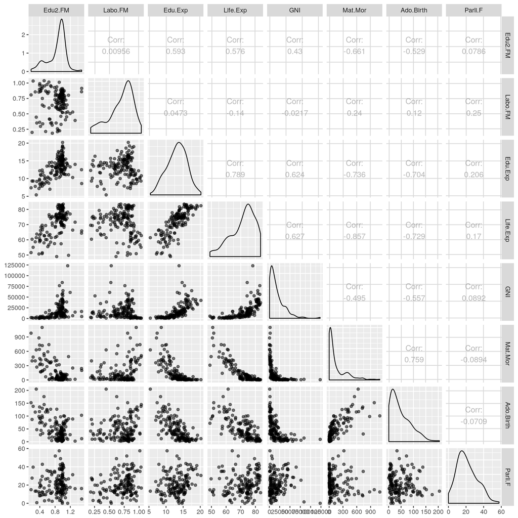

```r
library(ggplot2)
ggpairs(human, mapping = aes(alpha = 0.3), lower = list(combo = wrap("facethist")))
```

**Principal Component Analysis**

In the following section, we will summarize the principal components and make a principal component analysis (PCA) plot. Firse, PCA is done on non-standardized data followed up by standardized data.

```r
pca_human<-prcomp(human)
sum_pca_human<-summary(pca_human)
sum_pca_human
```

```
## Importance of components:
##                              PC1      PC2   PC3   PC4   PC5   PC6    PC7
## Standard deviation     1.854e+04 185.5219 25.19 11.45 3.766 1.566 0.1912
## Proportion of Variance 9.999e-01   0.0001  0.00  0.00 0.000 0.000 0.0000
## Cumulative Proportion  9.999e-01   1.0000  1.00  1.00 1.000 1.000 1.0000
##                           PC8
## Standard deviation     0.1591
## Proportion of Variance 0.0000
## Cumulative Proportion  1.0000
```

```r
sum_pca_human_var<-sum_pca_human$sdev^2
sum_pca_human_var
```

```
## [1] 3.438860e+08 3.441836e+04 6.343853e+02 1.312035e+02 1.418457e+01
## [6] 2.452081e+00 3.655943e-02 2.531638e-02
```

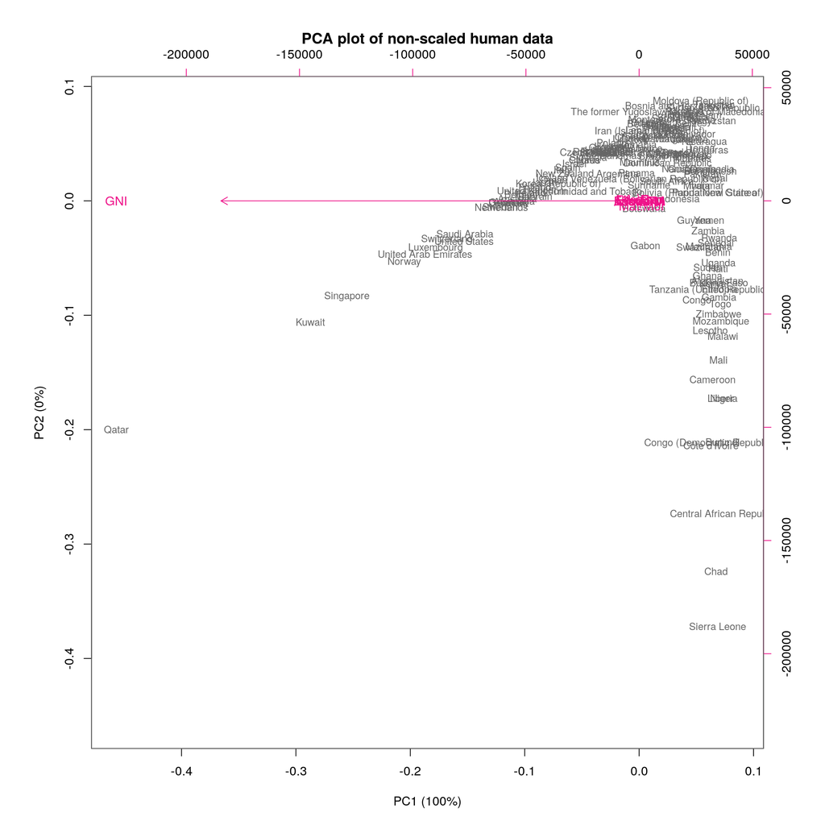

```r
pca_pr <- round(100*sum_pca_human$importance[2, ], digits = 1)
pc_lab<-paste0(names(pca_pr), " (", pca_pr, "%)")

biplot(pca_human, cex = c(0.8, 1), col = c("grey40", "deeppink2"), xlab = pc_lab[1], ylab = pc_lab[2], main = "PCA plot of non-scaled human data")
```

```r
#biplot(pca_human, choices = 1:2, cex = c(1, 1), col = c("grey40", "deeppink2"),sub = "PC1 & PC2 with non-standardised dataset")
```

The PCA biplot above does not provide meaningful interpration to the data as it shows that single variable *GNI* has dominant impact and greater weight. Moreover, *GNI* has larger variance compared to other variables.

**Data Standardization**

Next, we will scale the variables in the human data and compute principal components and plot the results.

```r
pca_human_s<-prcomp(human, scale. = TRUE)
sum_pca_human_s<-summary(pca_human_s)
pca_pr_s <- round(100*sum_pca_human_s$importance[2, ], digits = 1)
pc_lab<-paste0(names(pca_pr_s), " (", pca_pr_s, "%)")

sum_pca_human_var_s<-sum_pca_human_s$sdev^2
sum_pca_human_var_s
```

```
## [1] 4.2883701 1.2989625 0.7657100 0.6066276 0.4381862 0.2876242 0.2106805
## [8] 0.1038390
```

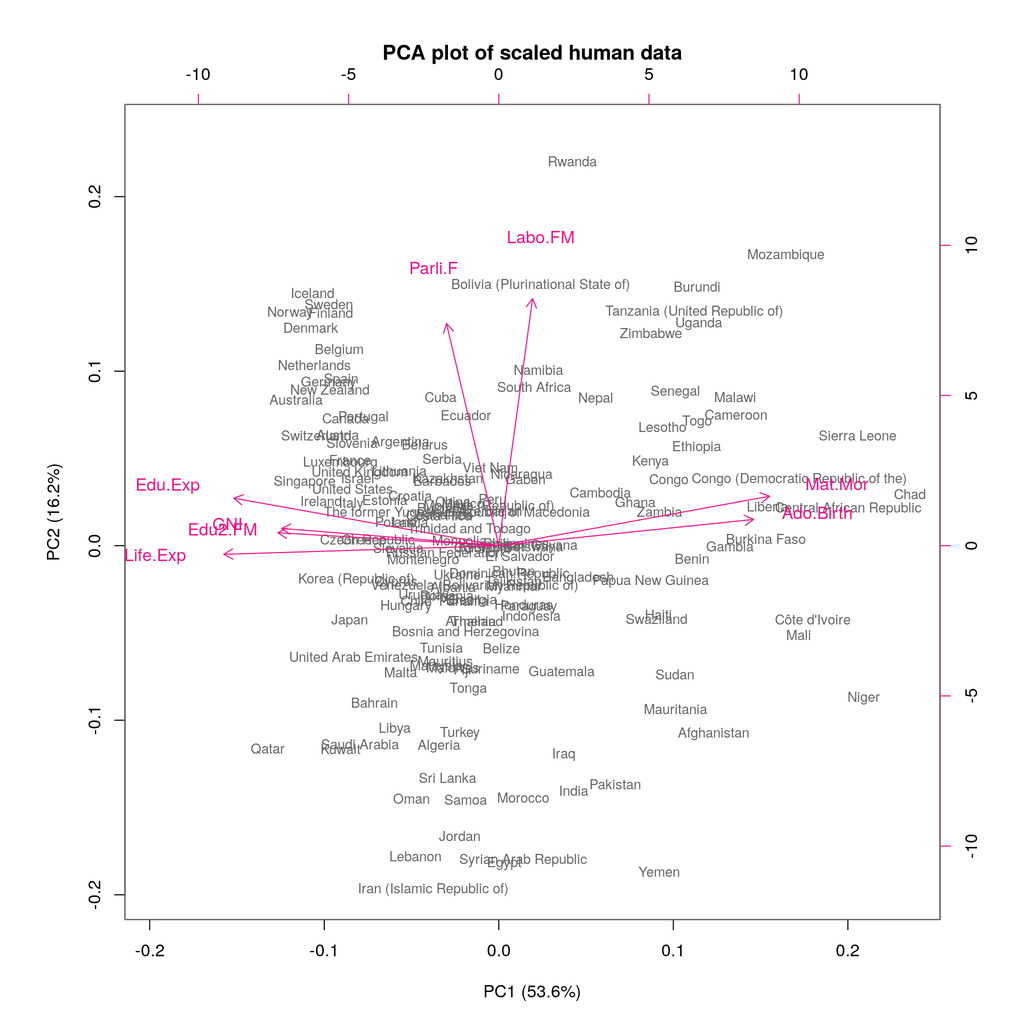

```r
biplot(pca_human_s, cex = c(0.8, 1), col = c("grey40", "deeppink2"), xlab = pc_lab[1], ylab = pc_lab[2], main = "PCA plot of scaled human data")
```

Here, after standardization, we can see that the plots look different and thus the results are different. The results are different after scaling because PCA is more sensitive and informative when the original features are scaled. Moreover, PCA assumes that features with lareger variance are more important that those with smaller variance. In non-scaled pca plot, we observed that the variable with higher values have bigger influence as is the case in *GNI* variable. After scaling the data, the variance between the variables is more reasonable. The first principal component (PC1) explains 53% of the variation compared to 100% when the data was not scaled. **Personal Interpretation on Biplot**

**Multiple Correspondence Analysis**

We will use tea data from FactoMineR package to practice multiple correspondence analysis (MCA). In this data, there are 300 observations and 36 variables.

```r
library(FactoMineR)
data("tea")
str(tea)
```

```
## 'data.frame':    300 obs. of  36 variables:
##  $ breakfast       : Factor w/ 2 levels "breakfast","Not.breakfast": 1 1 2 2 1 2 1 2 1 1 ...
##  $ tea.time        : Factor w/ 2 levels "Not.tea time",..: 1 1 2 1 1 1 2 2 2 1 ...
##  $ evening         : Factor w/ 2 levels "evening","Not.evening": 2 2 1 2 1 2 2 1 2 1 ...
##  $ lunch           : Factor w/ 2 levels "lunch","Not.lunch": 2 2 2 2 2 2 2 2 2 2 ...
##  $ dinner          : Factor w/ 2 levels "dinner","Not.dinner": 2 2 1 1 2 1 2 2 2 2 ...
##  $ always          : Factor w/ 2 levels "always","Not.always": 2 2 2 2 1 2 2 2 2 2 ...
##  $ home            : Factor w/ 2 levels "home","Not.home": 1 1 1 1 1 1 1 1 1 1 ...
##  $ work            : Factor w/ 2 levels "Not.work","work": 1 1 2 1 1 1 1 1 1 1 ...
##  $ tearoom         : Factor w/ 2 levels "Not.tearoom",..: 1 1 1 1 1 1 1 1 1 2 ...
##  $ friends         : Factor w/ 2 levels "friends","Not.friends": 2 2 1 2 2 2 1 2 2 2 ...
##  $ resto           : Factor w/ 2 levels "Not.resto","resto": 1 1 2 1 1 1 1 1 1 1 ...
##  $ pub             : Factor w/ 2 levels "Not.pub","pub": 1 1 1 1 1 1 1 1 1 1 ...
##  $ Tea             : Factor w/ 3 levels "black","Earl Grey",..: 1 1 2 2 2 2 2 1 2 1 ...
##  $ How             : Factor w/ 4 levels "alone","lemon",..: 1 3 1 1 1 1 1 3 3 1 ...
```

[output cut: 22 more lines]

```r
dim(tea)
```

```
## [1] 300  36
```

```r
summary(tea)
```

```
##          breakfast           tea.time          evening          lunch
##  breakfast    :144   Not.tea time:131   evening    :103   lunch    : 44
##  Not.breakfast:156   tea time    :169   Not.evening:197   Not.lunch:256
##
##
##
##
##
##         dinner           always          home           work
##  dinner    : 21   always    :103   home    :291   Not.work:213
##  Not.dinner:279   Not.always:197   Not.home:  9   work    : 87
##
##
##
##
##
##         tearoom           friends          resto          pub
##  Not.tearoom:242   friends    :196   Not.resto:221   Not.pub:237
##  tearoom    : 58   Not.friends:104   resto    : 79   pub    : 63
##
##
##
##
##
##         Tea         How           sugar                     how
##  black    : 74   alone:195   No.sugar:155   tea bag           :170
##  Earl Grey:193   lemon: 33   sugar   :145   tea bag+unpackaged: 94
##  green    : 33   milk : 63                  unpackaged        : 36
##                  other:  9
##
##
##
##                   where                 price          age        sex
##  chain store         :192   p_branded      : 95   Min.   :15.00   F:178
##  chain store+tea shop: 78   p_cheap        :  7   1st Qu.:23.00   M:122
##  tea shop            : 30   p_private label: 21   Median :32.00
##                             p_unknown      : 12   Mean   :37.05
##                             p_upscale      : 53   3rd Qu.:48.00
##                             p_variable     :112   Max.   :90.00
##
```

[output cut: 25 more lines]

```
##  feminine    :129   Not.sophisticated: 85   No.slimming:255
##  Not.feminine:171   sophisticated    :215   slimming   : 45
##
##
##
##
##
##         exciting          relaxing              effect.on.health
##  exciting   :116   No.relaxing:113   effect on health   : 66
##  No.exciting:184   relaxing   :187   No.effect on health:234
##
##
##
##
##
```

```r
library(tidyr)
library(dplyr)
```

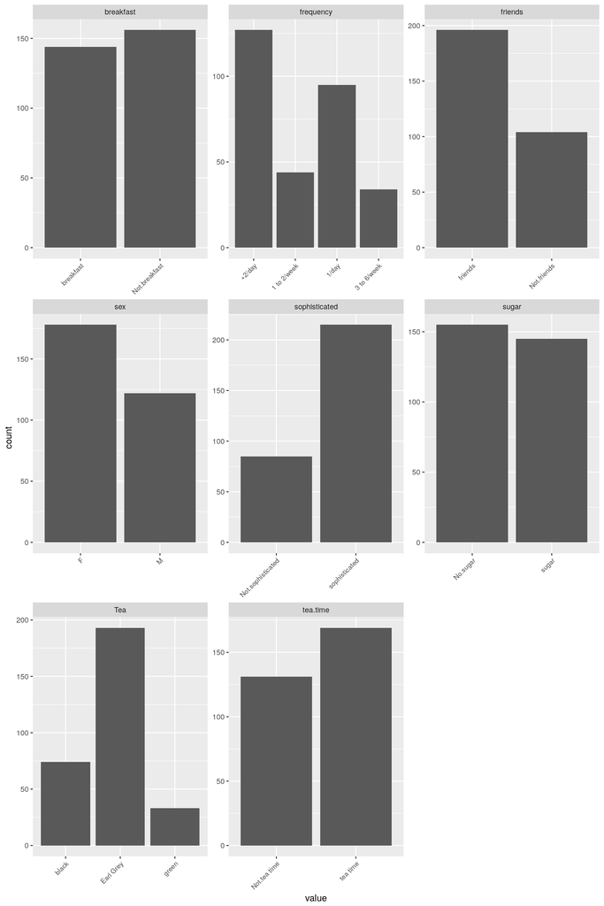

```r
keep<- c("breakfast","tea.time","friends","frequency","Tea","sugar","sex","sophisticated")
my_tea <- dplyr::select(tea, one_of(keep))
gather(my_tea) %>% ggplot(aes(value)) + geom_bar() + theme(axis.text.x = element_text(angle = 45, hjust = 1, size = 8)) + facet_wrap("key", scales = "free")
```

```r
mca_tea <- MCA(my_tea, graph=FALSE)
summary(mca_tea, nbelements=Inf, nbind=5)
```

```
##
## Call:
## MCA(X = my_tea, graph = FALSE)
##
##
## Eigenvalues
##                        Dim.1   Dim.2   Dim.3   Dim.4   Dim.5   Dim.6
## Variance               0.213   0.189   0.159   0.136   0.131   0.118
## % of var.             15.481  13.717  11.556   9.865   9.518   8.606
## Cumulative % of var.  15.481  29.198  40.754  50.619  60.137  68.743
##                        Dim.7   Dim.8   Dim.9  Dim.10  Dim.11
## Variance               0.112   0.093   0.091   0.072   0.061
## % of var.              8.150   6.766   6.644   5.254   4.444
## Cumulative % of var.  76.893  83.658  90.302  95.556 100.000
##
## Individuals (the 5 first)
##                      Dim.1    ctr   cos2    Dim.2    ctr   cos2    Dim.3
## 1                 |  0.359  0.202  0.071 |  1.116  2.201  0.686 | -0.040
## 2                 | -0.198  0.061  0.023 |  0.845  1.261  0.419 |  0.349
## 3                 | -0.484  0.367  0.226 | -0.243  0.105  0.057 | -0.211
## 4                 |  0.779  0.951  0.499 |  0.345  0.210  0.098 | -0.071
## 5                 | -0.065  0.007  0.003 |  0.816  1.176  0.480 | -0.026
##                      ctr   cos2
## 1                  0.003  0.001 |
## 2                  0.255  0.071 |
## 3                  0.094  0.043 |
## 4                  0.011  0.004 |
## 5                  0.001  0.000 |
##
## Categories
##                       Dim.1     ctr    cos2  v.test     Dim.2     ctr
## breakfast         |  -0.545   8.384   0.275  -9.060 |   0.576  10.563
## Not.breakfast     |   0.503   7.739   0.275   9.060 |  -0.532   9.750
## Not.tea time      |   0.663  11.263   0.340  10.090 |   0.345   3.447
## tea time          |  -0.514   8.730   0.340 -10.090 |  -0.268   2.672
## friends           |  -0.115   0.504   0.025  -2.721 |  -0.375   6.083
## Not.friends       |   0.216   0.950   0.025   2.721 |   0.706  11.465
## 1/day             |   0.296   1.631   0.041   3.487 |   0.609   7.774
## 1 to 2/week       |   1.072   9.899   0.198   7.686 |  -1.161  13.109
## +2/day            |  -0.727  13.148   0.388 -10.775 |   0.105   0.308
```

[output cut: 26 more lines]

```
## F                   0.186  -7.458 |   0.027   0.035   0.001   0.569 |
## M                   0.186   7.458 |  -0.040   0.051   0.001  -0.569 |
## Not.sophisticated   0.244   8.545 |  -0.564   7.100   0.126  -6.136 |
## sophisticated       0.244  -8.545 |   0.223   2.807   0.126   6.136 |
##
## Categorical variables (eta2)
##                     Dim.1 Dim.2 Dim.3
## breakfast         | 0.275 0.306 0.055 |
## tea.time          | 0.340 0.092 0.019 |
## friends           | 0.025 0.265 0.163 |
## frequency         | 0.449 0.359 0.030 |
## Tea               | 0.094 0.055 0.533 |
## sugar             | 0.233 0.001 0.344 |
## sex               | 0.286 0.186 0.001 |
## sophisticated     | 0.001 0.244 0.126 |
```

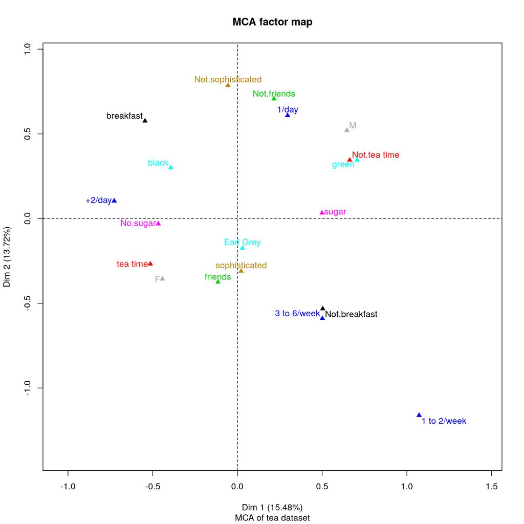

```r
plot(mca_tea, invisible = c("ind"), habillage = "quali", sub = "MCA of tea dataset")
```

In general, the MCA plot grouped the categories that are mutually similar together and vice versa. Categories such as **tea time**, **friends** are grouped together and such are the categories such as **Not friends** and **Not.tea time**. In other words, friends tend to have tea time together and those do not have tea during other times (i.e not tea times) are not close friends. Also, the plot shows that Females are more social than their male counter parts because they have friends, and participate during the tea time. It also showed that females do not put sugar whereas males put sugar in tea.